# Genotype QC to HRC ¦ Behar et al. 2010

DRAGON-Data Pipeline, Cardiff University

04-07-2024

# Dataset pre-processing

The PLINK files provided contain **555737** genotyped markers on **466** individuals.

Original PLINK files are available here.

Genotyped SNP content across chromosomes.

| Chromosome | Number of SNPs | Start basepair | End basepair |
| --- | --- | --- | --- |
| 1 | 42494 | 752566 | 249210707 |
| 2 | 45192 | 33012 | 243044147 |
| 3 | 37494 | 63411 | 197813975 |
| 4 | 33205 | 73508 | 190891703 |
| 5 | 33905 | 27564 | 180690937 |
| 6 | 36262 | 203909 | 170909002 |
| 7 | 29987 | 45653 | 159119486 |
| 8 | 31036 | 164984 | 146274708 |
| 9 | 26455 | 46587 | 141027939 |
| 10 | 29070 | 126070 | 135434303 |
| 11 | 26998 | 198510 | 134940416 |
| 12 | 26967 | 193818 | 133778796 |
| 13 | 20896 | 19210426 | 115103150 |
| 14 | 18243 | 20213937 | 107287663 |
| 15 | 16493 | 20161372 | 102397836 |
| 16 | 16766 | 97354 | 90149922 |
| 17 | 14350 | 51088 | 81041077 |
| 18 | 16626 | 69836 | 78015180 |
| 19 | 9468 | 266034 | 59087479 |
| 20 | 14024 | 63244 | 62912463 |
| 21 | 8158 | 10971951 | 48084989 |
| 22 | 8274 | 16504399 | 51178090 |
| X | 13235 | 2700157 | 154929412 |
| Y | 8 | 2668456 | 21896261 |
| XYPAR | 15 | 294201 | 155217992 |
| MTDNA | 116 | 217 | 16393 |

## Mitochondrial DNA

**116** SNPs were detected in the mitochondrial DNA. These have been separated into their own PLINK files and are available in the curated data folder.

## Chipendium

The most likely genotyping chip(s) was identified as **Human1-2M-DuoCustom_v1_A-b37 | Human1M-Duov3_B-b37** through a closest-match algorithm that found **540796** overlapping SNPs. Please see the legacy Chipendium [website](https://www.well.ox.ac.uk/~wrayner/strand/) for more information about this procedure. Details on updated versions of Chipendium (not implemented here) can be found at the Strand [website](https://www.strand.org.uk/).

# QC Step 1: Missingness Rates

## Samples

A large proportion of SNP assays failing on any single individual may be indicative of a poor quality DNA sample, which leads to aberrant genotype calling (Turner et al. 2011, PMID: [21234875](https://doi.org/10.1002%2F0471142905.hg0119s68)). These samples should be removed from the dataset.

Optimal genotyping coverage was set at 95% (red line). 0 individuals were removed due to low coverage.

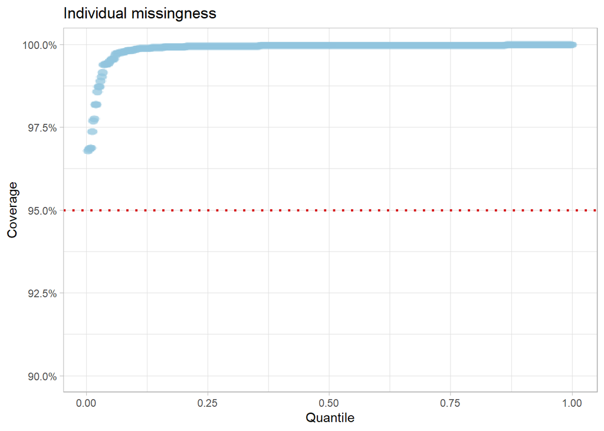

## SNPs

Markers in which the genotyping has performed poorly can be identified by assessing their call rates over the whole dataset after discarding problematic samples (Turner et al. 2011, PMID: [21234875](https://doi.org/10.1002%2F0471142905.hg0119s68)). SNPs with a low call rate are more likely to be affected by genotyping errors and should be excluded from further analyses.

Optimal per-marker call rate was set at 95% (red line). 0 SNPs were removed due to low call rate.

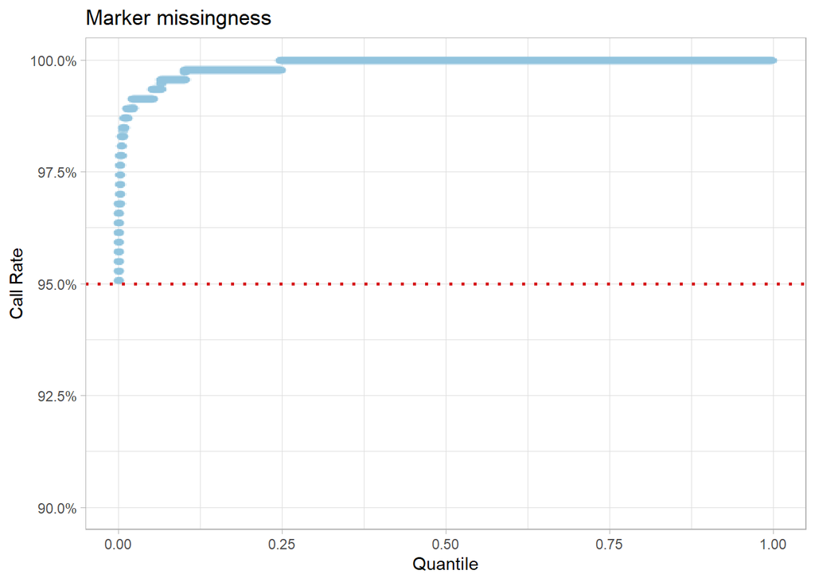

# QC Step 2: Hardy-Weinberg Equilibrium (HWE)

Allele frequencies in random-mating populations usually follow the Hardy-Weinberg proportions, unless they are under strong selective pressures. In the quality control of array datasets for GWAS, errors in genotyping tend to create deviations from HWE, as they result in a greater number of heterozygote calls (Graffelman 2017, PMID: [28374190](https://doi.org/10.1007/s00439-017-1786-7)).

The genome-wide significant p-value threshold for the Hardy-Weinberg Equilibrium exact test was set at 1.00e-06. 14 SNPs were removed due to deviations from HWE (red diamonds). The solid blue line indicates the expectation for the relationship between pairs of genotype frequencies according to the Hardy-Weinberg principles.

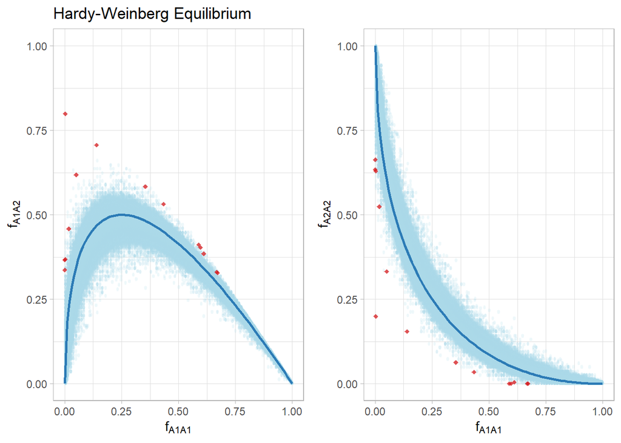

HWE testing was performed with two modifications implemented in the PLINK2 software [website](https://www.cog-genomics.org/plink/2.0/filter#hwe): Calculating a “mid” p-value instead of an exact p-value (Graffelman & Moreno 2013, PMID: [23934608](https://doi.org/10.1515/sagmb-2012-0039)), and performing a one-sided test for markers with few heterozygote calls to account for the [Wahlund effect](https://doi.org/10.1002/9780470015902.a0005446.pub3) caused by population stratification (Lee 2003, PMID: [21184275](https://doi.org/10.1093/aje/kwg150)).

# QC Step 3: Sex chromosome checks

This test assesses homozygosity estimates from the X chromosome using the inbreeding coefficient F (Wright 1921, PMID: [17245962](https://doi.org/10.1093/genetics/143.4.1499)) calculated for each sample using LD-independent X-linked markers ($r^{2} \le 0.2$). Samples at the extremes of the distribution of the F statistic are likely genetic females (low F) or genetic males (high F). Coverage for Y-linked markers can also be inspected to more accurately infer the sex of ambiguous samples. Furthermore, the combination of both metrics can pinpoint individuals as potential carriers of sex chromosome aneuploidies such as the Turner (X0; high F and low Y coverage) or Klinefelter (XXY; low F and high Y coverage) syndromes (Igo et al. 2016, PMID: [27367164](https://doi.org/10.1002%2Fcphg.15)).

Homozygosity thresholds (red lines) set at 0.2 for genetic females and 0.8 for genetic males. 3 individuals were seen between both values. 1 individuals were identified as potentially having an abnormal sex chromosome karyotype (orange diamonds), and could benefit from addional quality control if raw genotype intensity data is available.

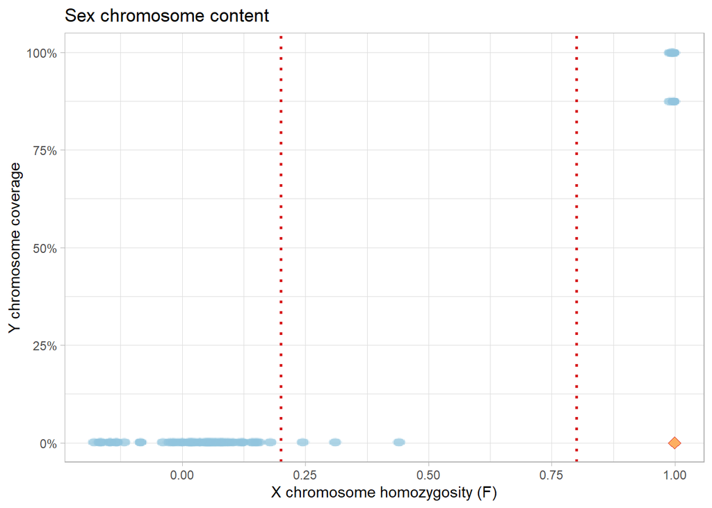

In some cases, Y chromosome coverage rates of female samples can be >10%, though there should still be a clear difference between female and male samples in this metric. This is an issue [reported](https://groups.google.com/g/plink2-users/c/wzTNgigro-Q/m/wUq3xIz6whkJ) for some legacy genotyping arrays where autosomal or X-linked probes were erroneously coded as Y-linked.

# QC Step 4: Population structure and in-sample relatedness

PC-AiR (Conomos et al. 2015, PMID: [25810074](https://doi.org/10.1002/gepi.21896)) was performed using the implementation in the [GENESIS](https://bioconductor.org/packages/release/bioc/html/GENESIS.html) software suite. This is a modified version of the Principal Components Analysis (PCA) approach for the detection of population structure in genome-wide data. Unlike the standard method, PC-AiR may be used if some individuals in the sample are closely related, as it generates principal components that are robust to family structure.

Results from a PC-AiR analysis on 105192 LD-independent markers outside of genomic regions with long-range LD. Red lines indicate the area delimited by the mean +/- 1.96 standard deviations of the first two principal components.

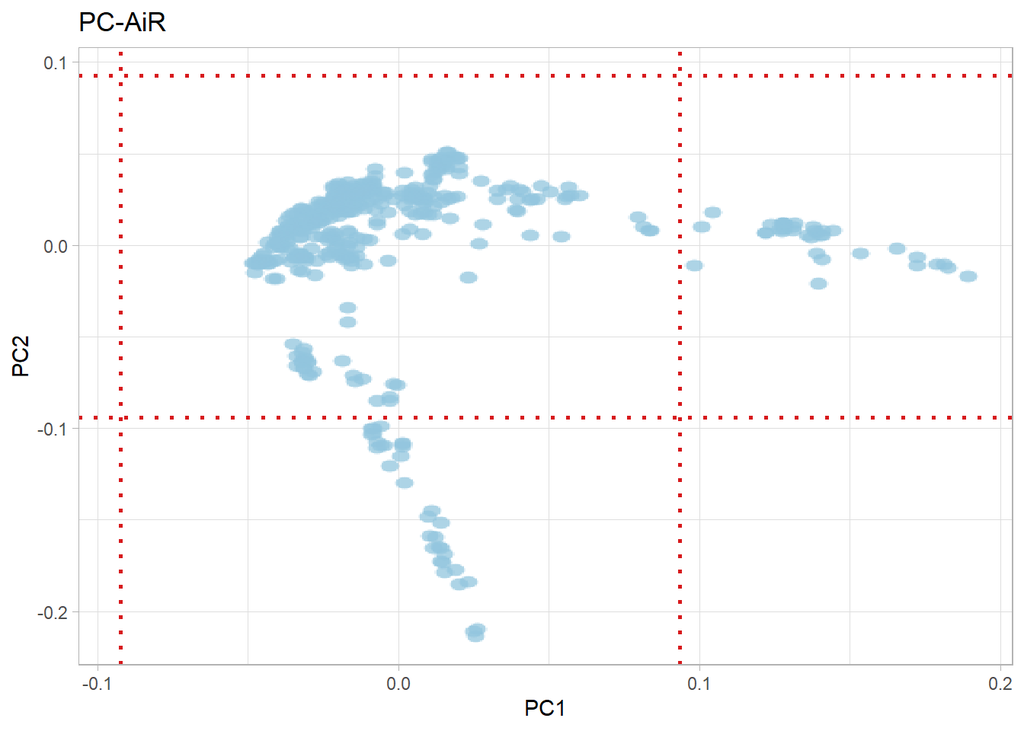

The output of PC-AiR can be used by PC-Relate (Conomos et al. 2016, PMID: [26748516](https://doi.org/10.1016/j.ajhg.2015.11.022)), an approach to de-confound estimates of genetic kinship from population structure. The PC-Relate coefficient $\Phi$ can be interpreted in the same way as the PLINK metric $\hat\pi{}$ to identify groups of related individuals (Manichaikul et al. 2010, PMID: [20926424](https://doi.org/10.1093%2Fbioinformatics%2Fbtq559)).

For each pair of samples in the dataset, the plot shows proportions of markers with no identical-by-descent (IBD) alleles and estimated kinship values. These have been corrected using 5 principal components and rescaled to the equivalent PLINK metric. 13 pairs of individuals have a relatedness coefficient greater than 0.09375 (red line). Among those, 3 pairs have been identified as potentially duplicated samples or monozygotic twins.

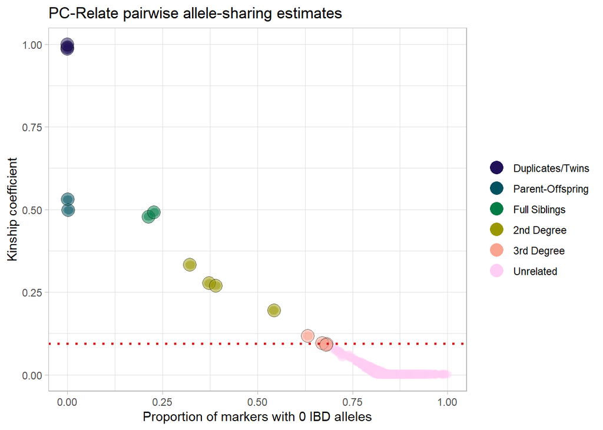

# QC Step 5: Biogeographic ancestry inference

These analyses are based on the procedure described in Legge et al. 2019 (PMID: [30647433](https://doi.org/10.1038/s41380-018-0335-7)) and updated in Smart et al. 2024 (in prep). The biogeographic ancestries inferred are based on the standardised system by Huddart et al. 2019 (PMID: [30506572](https://doi.org/10.1002/cpt.1322)).

**2490** unrelated individuals from the 1000 Genomes Phase 3 (Auton et al. 2015; PMID: [26432245](https://doi.org/10.1038/nature15393)) were used to infer Ancestry Informative Markers (AIMs). These were defined as LD-independent variants overlapping the input dataset, outside of genomic regions with long-range LD (Price et al. 2008; PMID: [18606306](https://doi.org/10.1016/j.ajhg.2008.06.005)), and with a Wright’s F<sub>ST</sub> value above the 97.5th percentile in at least one pairwise population comparison. The input and reference datasets were then trimmed to contain only AIMs and merged. Only 6 (out of 9) ancestries are available in this reference dataset.

Results from a PC-AiR analysis on 39637 AIMs. 100 principal components were computed in the reference samples. Using the “prediction” algorithm implemented in PC-AiR, the input dataset samples (grey squares) were projected into the reference PC-coordinates.

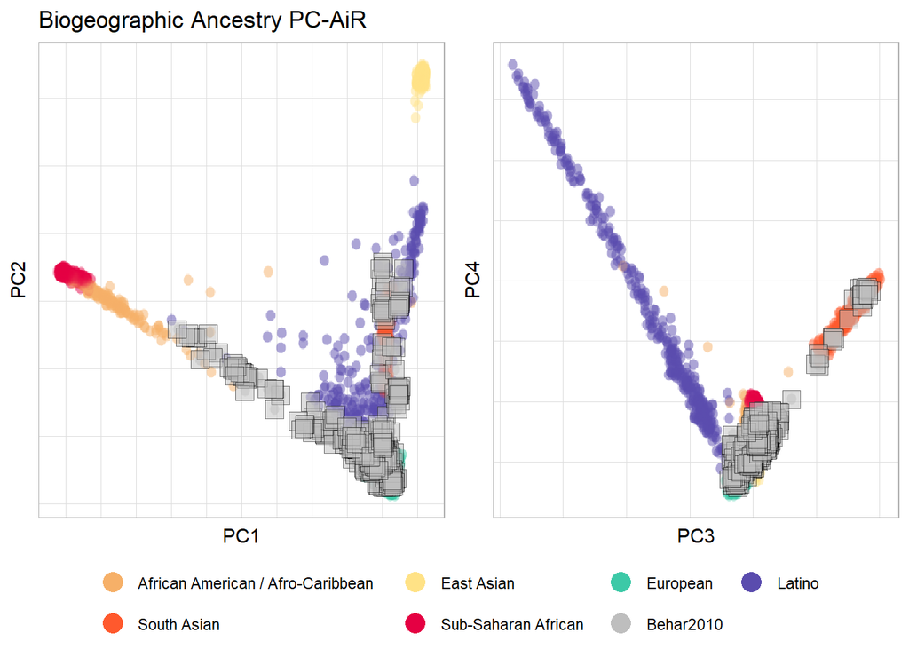

The Tracy-Widom test (Patterson et al. 2006; PMID: [17194218](https://doi.org/10.1371%2Fjournal.pgen.0020190)) selected the 39 first eigenvectors of the dataset for the ancestry inference procedure. A model based on Fisher’s Linear Discriminant Analysis (Yang et al. 2005; PMID: [16193326](https://doi.org/10.1007/s00439-005-0012-1)) was trained on the known ancestries of the reference samples with principal components as predictors.

LDA model training statistics, based on 5 repeats of a 10-foldcross-validation routine.

| Biogeographic Ancestry | Prevalence | Sensitivity | Specificity | Balanced Accuracy |
| --- | --- | --- | --- | --- |
| African American / Afro-Caribbean | 4.88% | 97.53% | 98.67% | 98.10% |
| East Asian | 20.24% | 100.00% | 100.00% | 100.00% |
| European | 20.58% | 98.17% | 100.00% | 99.08% |
| Latino | 13.52% | 99.41% | 99.42% | 99.41% |
| Central / South Asian | 19.44% | 100.00% | 100.00% | 100.00% |
| Sub-Saharan African | 21.34% | 94.47% | 100.00% | 97.23% |

The trained LDA classification model was then applied to the principal components of the input dataset to predict the most likely ancestral category of each sample. A threshold for ancestry inference was set by finding, for each ancestral category, the probability cutoff maximising the value of Youden’s J index (Perkins & Schisterman 2006; PMID: [16410346](https://doi.org/10.1093/aje/kwj063)). To avoid assigning any individual to multiple ancestries, only probability cutoffs greater than 0.501 were evaluated.

LDA model results.

| Predicted Biogeographic Ancestry | Probability Threshold | Number of Samples |
| --- | --- | --- |
| Unclassified | NA | 9 |
| African American / Afro-Caribbean | 0.501 | 29 |
| East Asian | 0.501 | 0 |
| European | 0.999 | 381 |
| Latino | 0.501 | 19 |
| Central / South Asian | 0.501 | 28 |
| Sub-Saharan African | 0.977 | 0 |

For **9** individuals none of the ancestral probabilities reach their optimal probability threshold. These individuals have been labelled *“Unclassified”*. Detailed inspection of ancestral probabilities is recommended to evaluate the potential admixture patterns of unclassified individuals.

# Additional Operations

## Harmonisation to imputation reference

[Genotype Harmonizer](https://github.com/molgenis/systemsgenetics/wiki/Genotype-Harmonizer) was used to align curated markers to the Haplotype Reference Consortium ([HRC](http://www.haplotype-reference-consortium.org/)) imputation panel. **553830** markers were successfully harmonised. Per-chromosome block-gzipped VCFs have been created for submission to the [Michigan Imputation Server](https://imputationserver.sph.umich.edu/).

# Output file location

**555723** markers and **466** individuals passed all quality control checks.

Curated genotype files.

Reference and merged files used for ancestry inference.

Imputation-ready files generated by Genotype Harmonizer.

Parent folder including all intermediate genotype files.

**NOTE:** Curated files are provided in PLINK2 *.pgen/.psam/.pvar* format, but are identical in marker and sample content to intermediate *.qc2* files in PLINK1 *.bed/.bim/.fam* format.